# Mapping meta-analyses on organochlorine pesticides reveals low methodological quality

## Bar plot for subjects investigated

A bar plot showing the percentage and total count of total of subjects investigate in meta-analysis investigating the impacts of organochlorine pesticides. Note: some meta-analysis may contribute to multiple sections if the study involves multiple subjects

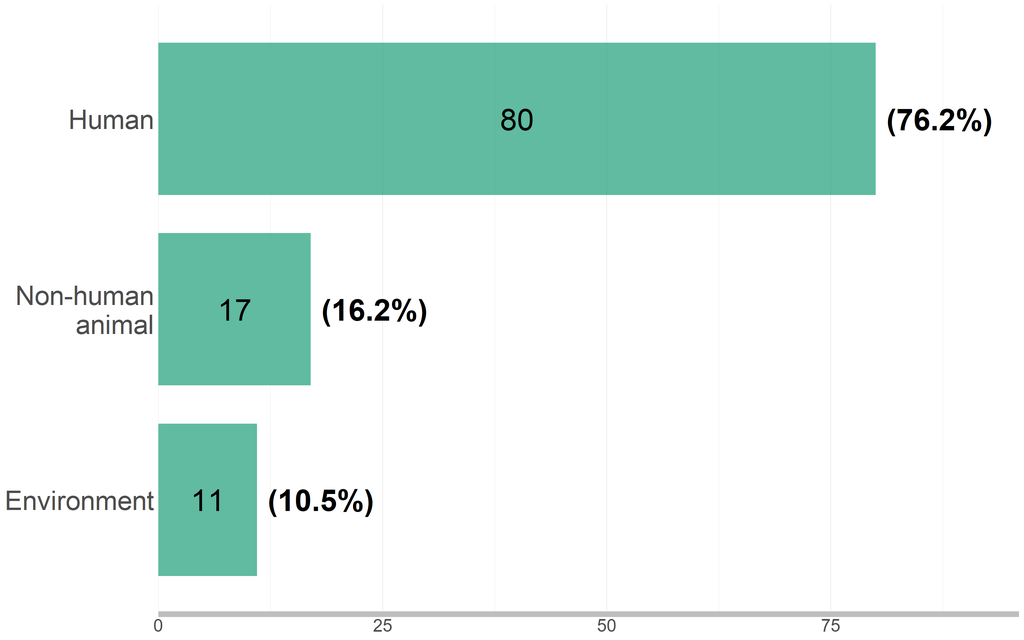

```r
# Calculate total count for each category
subject_count <- sub %>%
  separate_rows(subject, sep = ",\\s+") %>%
  mutate(subject = ifelse(grepl("Non-human animal", subject, ignore.case = TRUE),
                          "Non-human\nanimal", subject)) %>%
  count(subject)

# Calculate proportion and percentage for each category
subject_pct <- subject_count %>%
  mutate(proportion = n / 105,
         percentage = proportion * 100)

# Create the count plot for subjects
bar_plot_subject <- subject_count %>%
  ggplot(aes(x = n, y = reorder(subject, n), fill = "#1b9e77")) +
  geom_bar(stat = "identity", width = 0.8 , alpha = 0.7) +
  geom_text(aes(label = n, x = n / 2, y = reorder(subject, n)),
            hjust = 0.5, size = 12, color = "black") +
  geom_text(data = subject_pct,
            aes(label = paste0("(", round(percentage, 1), "%)"), x = n),
            hjust = -0.1, size = 12, color = "black", fontface = "bold") +
  scale_fill_identity(guide = "none") +
  scale_x_continuous(name = "Article Count", expand = c(0, 0), limits = c(0, max(subject_count$n)*1.2)) +
  labs(title = NULL, x = NULL, y = NULL) +
  organochlorTHEME()

bar_plot_subject
```

```r
# ggsave(here("figures", "bar_plot_subject_investigation.pdf"),
#        plot = bar_plot_subject, width = 25, height = 15, units = "cm", scale = 2, dpi = 800)
# ggsave(here("figures", "bar_plot_subject_investigation.svg"),
#        plot = bar_plot_subject, width = 25, height = 15, units = "cm", scale = 2, dpi = 800)
```

## Bar plot for impacts investigated (filtered)

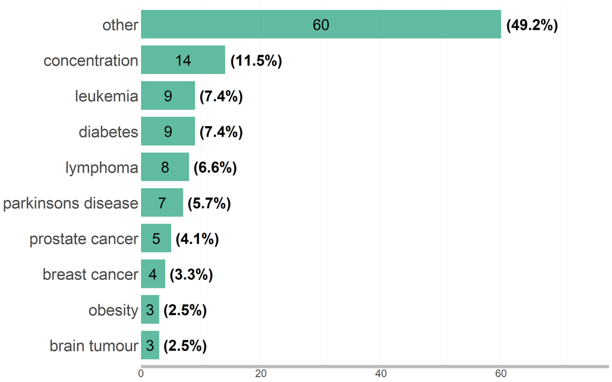

```r
# Calculate total count for each category
impact_count <- im %>%
  separate_rows(impact, sep = ",\\s+") %>%
  count(impact) %>%
  filter(impact != "NA") %>%
  mutate(impact = ifelse(n <= 2, "other", as.character(impact))) %>%
  group_by(impact) %>%
  summarise(n = sum(n))

# Calculate proportion and percentage for each category
impact_pct <- impact_count %>%
  mutate(proportion = n / sum(impact_count$n),
         percentage = proportion * 100)

# Create the count plot for impacts
bar_plot_impact_filtered <- impact_count %>%
  ggplot(aes(x = n, y = reorder(impact, n), fill = "#1b9e77")) +
  geom_bar(stat = "identity", width = 0.8 , alpha = 0.7) +
  geom_text(aes(label = n, x = n / 2, y = reorder(impact, n)),
            hjust = 0.5, size = 10, color = "black") +
  geom_text(data = impact_pct,
            aes(label = paste0("(", round(percentage, 1), "%)"), x = n),
            hjust = -0.1, size = 10, color = "black", fontface = "bold") +
  scale_fill_identity(guide = "none") +
  scale_x_continuous(name = "Article Count", expand = c(0, 0), limits = c(0, max(impact_count$n)*1.3)) +
  labs(title = NULL, x = NULL, y = NULL) +
  organochlorTHEME()

bar_plot_impact_filtered
```

```r
# ggsave(here("figures", "bar_plot_impact_investigated_filtered.pdf"),
#        plot = bar_plot_impact_filtered, width = 25, height = 15, units = "cm", scale = 2, dpi = 800)
# ggsave(here("figures", "bar_plot_impact_investigated_filtered.jpg"),
#        plot = bar_plot_impact_filtered, width = 25, height = 15, units = "cm", scale = 2, dpi = 800)
```

## Bar plot for broad impact categories

A bar plot showing the percentage and total count of total of impact categories investigated in meta-analysis investigating the impacts of organochlorine pesticides. Note: some meta-analysis may contribute to multiple sections if the study involves multiple impacts

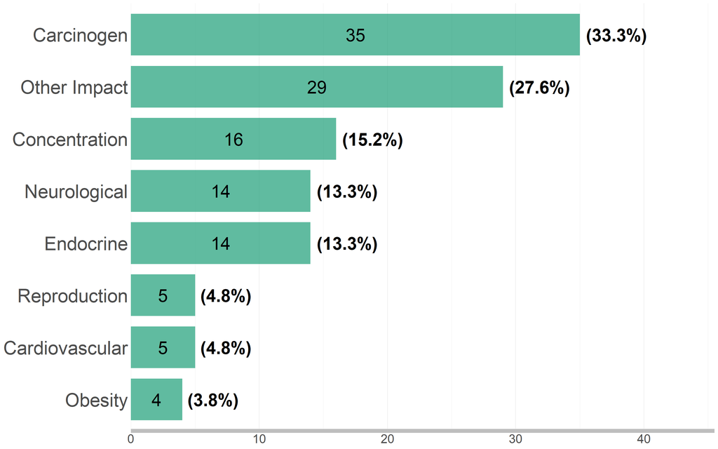

```r
# Create a column for broad impacts
im <- im %>%
  separate_rows(impact, sep = ",\\s+") %>%
  mutate(impact_broad = case_when(
    impact %in% c("parkinsons disease", "alzheimers disease", "autism spectrum disorder",
                  "brain tumour", "amyotrophic lateral sclerosis") ~ "Neurological",
    impact %in% c("concentration", "contamination") ~ "Concentration",
    impact %in% c("diabetes", "thyroid function", "hypertension", "endometriosis") ~ "Endocrine",
    grepl("cancer", impact, ignore.case = TRUE) |
      impact %in% c("leukemia", "lymphoma", "multiple myeloma", "neuroblastoma") ~ "Carcinogen",
    impact %in% c("respiratory health", "cardiovascular disease", "asthma", "prolonged bradycardia") ~ "Cardiovascular",
    impact %in% c("obesity", "adiposity") ~ "Obesity",
    impact %in% c("sperm quality", "neuroblastoma", "hypospadias", "cryptochidism",
                  "reproductive system") ~ "Reproduction",
    TRUE ~ "Other Impact"
  ))

# Calculate total count for each category
impact_count_broad <- im %>%
  separate_rows(impact_broad, sep = ",\\s+") %>%
  count(impact_broad) %>%
  filter(impact_broad != "NA") %>%
  group_by(impact_broad) %>%
  summarise(n = sum(n))

# Calculate proportion and percentage for each category
impact_pct_broad <- impact_count_broad %>%
  mutate(proportion = n / 105,
         percentage = proportion * 100)

# Create the count plot for impacts
bar_plot_impact_broad <- impact_count_broad %>%
  ggplot(aes(x = n, y = reorder(impact_broad, n), fill = "#1b9e77")) +
  geom_bar(stat = "identity", width = 0.8 , alpha = 0.7) +
  geom_text(aes(label = n, x = n / 2, y = reorder(impact_broad, n)),
            hjust = 0.5, size = 10, color = "black") +
  geom_text(data = impact_pct_broad,
            aes(label = paste0("(", round(percentage, 1), "%)"), x = n),
            hjust = -0.1, size = 10, color = "black", fontface = "bold") +
  scale_fill_identity(guide = "none") +
  scale_x_continuous(name = "Article Count", expand = c(0, 0), limits = c(0, max(impact_count_broad$n)*1.3)) +
  labs(title = NULL, x = NULL, y = NULL) +
  organochlorTHEME()

bar_plot_impact_broad
```

```r
# ggsave(here("figures", "bar_plot_broad_impact_category.pdf"),
#        plot = bar_plot_impact_broad, width = 25, height = 15, units = "cm", scale = 2, dpi = 800)
# ggsave(here("figures", "bar_plot_broad_impact_category.svg"),
#        plot = bar_plot_impact_broad, width = 25, height = 15, units = "cm", scale = 2, dpi = 800)
```

## Alluvial plot: pesticide exposure, subject, and impact

An alluvial plot showing the relationships between the pesticide of exposure, the subject being exposed and the impact of exposure

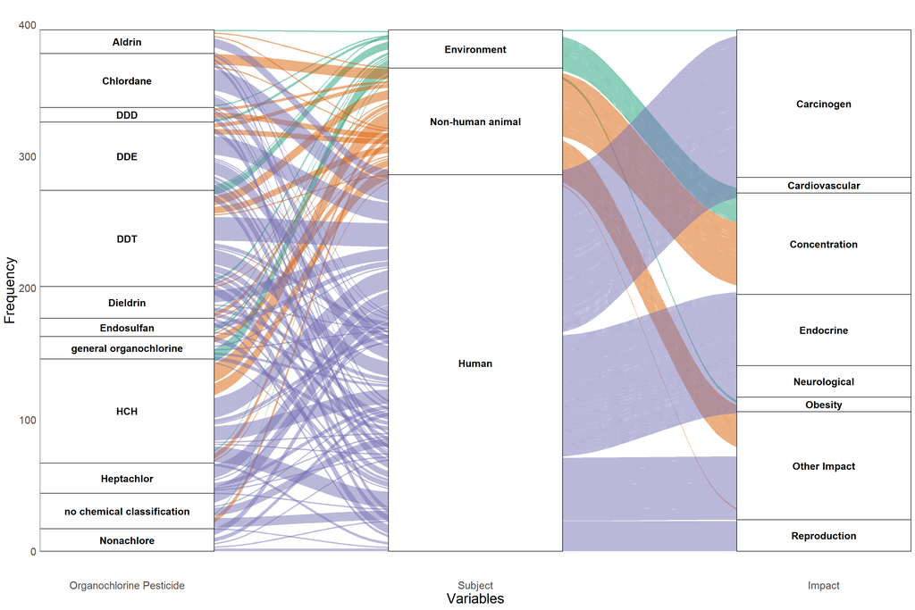

```r
# Function to change OCP to be more general
replace_ocp2 <- function(df) {
  df %>%
    mutate(ocp = case_when(
      grepl("Chlordane", ocp, ignore.case = TRUE) ~ "Chlordane",
      grepl("Endosulfan", ocp, ignore.case = TRUE) ~ "Endosulfan",
      grepl("Nonachlor", ocp, ignore.case = TRUE) ~ "Nonachlore",
      grepl("Heptachlor", ocp, ignore.case = TRUE) ~ "Heptachlor",
      grepl("TCDD", ocp, ignore.case = TRUE) ~ "TCDD",
      grepl("Endrin", ocp, ignore.case = TRUE) ~ "Endrin",
      grepl("Hexachlorobenzene", ocp, ignore.case = TRUE) ~ "HCH",
      grepl("Lindane", ocp, ignore.case = TRUE) ~ "HCH",
      grepl("Hexachlorocyclohexane \\(HCH\\)", ocp, ignore.case = TRUE) ~ "HCH",
      grepl("alpha-Hexachlorocyclohexane \\(alpha-HCH\\)", ocp, ignore.case = TRUE) ~ "HCH",
      grepl("beta-Hexachlorocyclohexane \\(beta-HCH\\)", ocp, ignore.case = TRUE) ~ "HCH",
      grepl("gamma-Hexachlorocyclohexane \\(gamma-HCH\\)", ocp, ignore.case = TRUE) ~ "HCH",
      grepl("Dichlorodiphenyltrichloroethane \\(DDT\\)", ocp, ignore.case = TRUE) ~ "DDT",
      grepl("p,p-Dichlorodiphenyltrichloroethane \\(p,p-DDT\\)", ocp, ignore.case = TRUE) ~ "DDT",
      grepl("o,p-Dichlorodiphenyltrichloroethane \\(o,p-DDT\\)", ocp, ignore.case = TRUE) ~ "DDT",
      grepl("Dichlorodiphenyldichloroethane \\(DDD\\)", ocp, ignore.case = TRUE) ~ "DDD",
      grepl("p,p-Dichlorodiphenyldichloroethane \\(p,p-DDD\\)", ocp, ignore.case = TRUE) ~ "DDD",
      grepl("o,p-Dichlorodiphenyldichloroethane \\(o,p-DDD\\)", ocp, ignore.case = TRUE) ~ "DDD",
      grepl("Dichlorodiphenyldichloroethylene \\(DDE\\)", ocp, ignore.case = TRUE) ~ "DDE",
      grepl("p,p-Dichlorodiphenyldichloroethylene \\(p,p-DDE\\)", ocp, ignore.case = TRUE) ~ "DDE",
      grepl("o,p-Dichlorodiphenyldichloroethylene \\(o,p-DDE\\)", ocp, ignore.case = TRUE) ~ "DDE",
      TRUE ~ ocp
    ))
}

# Transform the data
alluvial_data <- im %>%
  left_join(ocp, by = "study_id") %>%
  left_join(sub, by = "study_id") %>%
  separate_rows(subject, sep = ",\\s+") %>%
  separate_rows(ocp, sep = ",\\s+") %>%
  separate_rows(impact_broad, sep = ",\\s+") %>%
  replace_ocp2() %>%
  filter(!grepl("not reported", ocp, ignore.case = TRUE)) %>%
  group_by(ocp, subject, impact_broad) %>%
  summarise(freq = n(), .groups = 'drop') %>%
  group_by(ocp) %>%
  filter(sum(freq) > 10) %>%
  group_by(impact_broad) %>%
  filter(sum(freq) > 5) %>%
  mutate(subject = factor(subject, levels = c("Environment", "Non-human animal", "Human"), ordered = TRUE))

# Make alluvial plot
alluvial_plot_exposure <- alluvial_data %>%
  ggplot(aes(axis1 = ocp, axis2 = subject, axis3 = impact_broad, y = freq)) +
  scale_x_discrete(limits = c("Organochlorine Pesticide", "Subject", "Impact"), expand = c(.05, .10)) +
  xlab("Variables") +
  ylab("Frequency") +
  geom_alluvium(aes(fill = subject)) +
  geom_stratum(width = 1/2, fill = "white", color = "black") +
  geom_text(stat = "stratum", aes(label = after_stat(stratum)), size = 5, fontface = "bold") +
  theme_minimal() +
  theme(axis.text = element_text(size = 15),
        axis.title = element_text(size = 20),
        legend.position = "none",
        panel.grid.major = element_blank(),
        panel.grid.minor = element_blank()) +
  scale_fill_brewer(palette = "Dark2", name = "Subject Category")

alluvial_plot_exposure
```

```r
# ggsave(here("figures", "alluvial_plot_exposure_subject_impact.pdf"),
#        plot = alluvial_plot_exposure, width = 25, height = 15, units = "cm", scale = 2, dpi = 800)
# ggsave(here("figures", "alluvial_plot_exposure_subject_impact.jpg"),
#        plot = alluvial_plot_exposure, width = 25, height = 15, units = "cm", scale = 2, dpi = 800)


# ggsave(here("figures", "figs29.pdf"), width =18, height = 12, units = "cm", scale = 2, dpi = 800)
# ggsave(here("figures", "figs29.jpg"), width = 18, height = 12, units = "cm", scale = 2, dpi = 800)
```

## Figure 4

A bubble plot showing the counts of each pesticide per impact included in current meta-analysis on the impacts of organochlorine pesticides

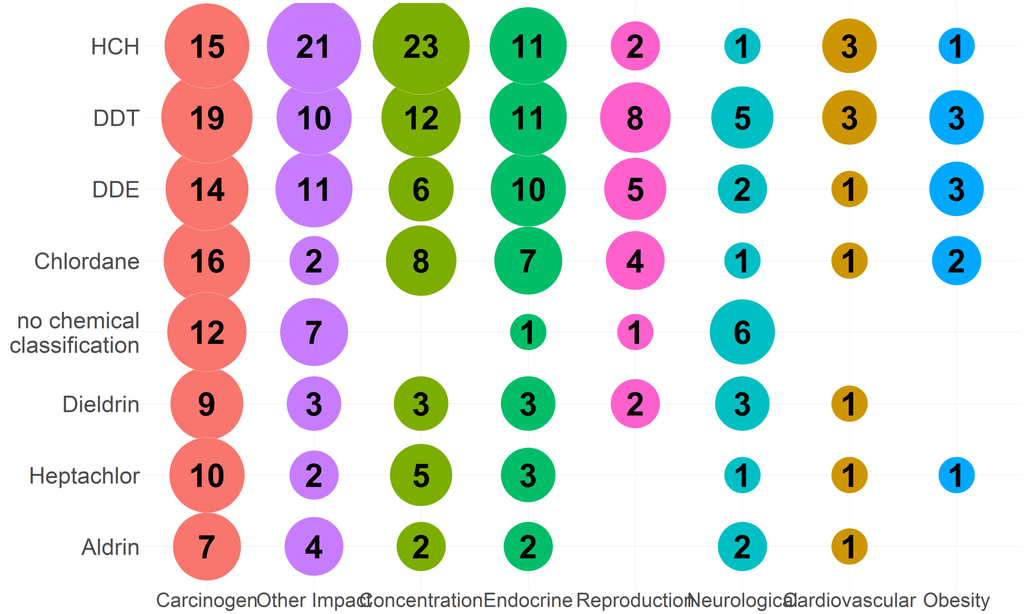

```r
# Join the organochlorine pesticide details with the impact details
ocp_im <- left_join(ocp, im ,sub, by = "study_id")

# Separate rows in "ocp_im"
ocp_im1 <- separate_rows(ocp_im, ocp , sep = ", ", convert = TRUE)


# Group by "ocp" and "impact" and summarize count
ocp_im_summary <- ocp_im1 %>%
  mutate(ocp = str_trim(ocp),
         impact_broad = str_trim(impact_broad)) %>%
    replace_ocp2() %>%
  group_by(ocp, impact_broad) %>%
  summarise(count = n(), .groups = "drop") %>%
  mutate(ocp = ifelse(grepl("no chemical classification", ocp, ignore.case = TRUE), "no chemical\n classification", ocp))

# Filter for top 8 pesticides
top_pesticides <- ocp_im_summary %>%
  filter(ocp != "not reported") %>%
  group_by(ocp) %>%
  summarise(total_count = sum(count)) %>%
  top_n(8, total_count) %>%
  pull(ocp)


ocp_im_summary_filtered <- ocp_im_summary %>%
  filter(ocp %in% top_pesticides)

fig4 <- ocp_im_summary_filtered %>%
  ggplot(aes(x = fct_rev(fct_reorder(impact_broad, count, .fun = 'sum')),
             y = fct_reorder(ocp, count, .fun = 'sum'),
             size = count,
             fill = impact_broad)) +
  geom_point(shape = 21, color = "white") +
  geom_text(aes(label = count), size = 20, fontface = "bold") +
  labs(title = NULL, x = NULL, y =NULL) +
  theme_minimal() +
  theme(
    axis.text.x = element_text(size = 35),
    axis.text.y = element_text(size = 40, hjust = 1),
    legend.position = "none") +
  scale_size_continuous(range = c(30, 80))

fig4
```

```r
 ggsave(here("figures", "fig4.pdf"), width = 40, height = 25, units = "cm", scale = 2, dpi = 800)
 ggsave(here("figures", "fig4.svg "), width = 40, height = 25, units = "cm", scale = 2, dpi = 800)
```

[output not shown]

# Section 3

To investigate global research output and collaboration networks

## Exploratory bibliometric analysis

[figure not shown]

[figure not shown]

[figure not shown]

[figure not shown]

[figure not shown]

```r
# Perform bibliometric analysis
bibliometric_analysis <- biblioAnalysis(bib_sco)

# Adjust plot parameters
par(cex=1.5)

# Explore results
plot(bibliometric_analysis)
```

```r
summary(bibliometric_analysis)
```

```
##
##
## MAIN INFORMATION ABOUT DATA
##
##  Timespan                              1993 : 2022
##  Sources (Journals, Books, etc)        45
##  Documents                             100
##  Annual Growth Rate %                  9.25
##  Document Average Age                  9.78
##  Average citations per doc             58.6
##  Average citations per year per doc    5.07
##  References                            7548
##
## DOCUMENT TYPES
##  article               50
##  conference paper      2
##  review                48
##
## DOCUMENT CONTENTS
##  Keywords Plus (ID)                    1592
##  Author's Keywords (DE)                258
##
## AUTHORS
##  Authors                               544
##  Author Appearances                    684
##  Authors of single-authored docs       1
##
## AUTHORS COLLABORATION
##  Single-authored docs                  1
##  Documents per Author                  0.184
##  Co-Authors per Doc                    6.84
##  International co-authorships %        41
##
##
## Annual Scientific Production
##
##  Year    Articles
##     1993        1
##     1995        1
##     1999        1
```

[output cut: 101 more lines]

```
##
##
## Most Relevant Keywords
##
##    Author Keywords (DE)      Articles Keywords-Plus (ID)     Articles
## 1      META-ANALYSIS               43 ENVIRONMENTAL EXPOSURE       92
## 2      PESTICIDES                  28 HUMAN                        84
## 3      SYSTEMATIC REVIEW           18 PESTICIDE                    79
## 4      OCCUPATIONAL EXPOSURE        8 HUMANS                       71
## 5      DDT                          7 FEMALE                       70
## 6      CHILD                        6 META ANALYSIS                64
## 7      DDE                          5 PESTICIDES                   60
## 8      BREAST CANCER                4 OCCUPATIONAL EXPOSURE        57
## 9      INSECTICIDES                 4 MALE                         56
## 10     ORGANOCHLORINES              4 PRIORITY JOURNAL             53
```

```r
str(bibliometric_analysis)
```

[output not shown]

## Bar plot of most productive countries

Most productive countries for meta-analyses included in the systematic review map Blue is for single country publications (i.e., countries with authors from a single country) and red is for multiple country publications (i.e., countries with authors from multiple countries).

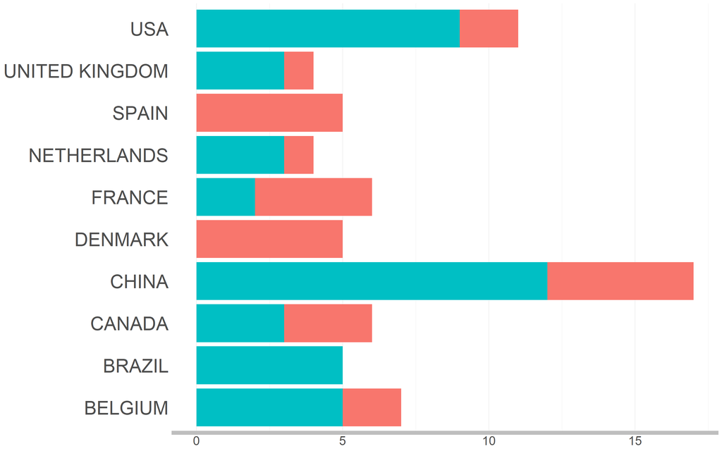

```r
# Extract country collaboration information
country_data <- bibliometric_analysis$CountryCollaboration
country_tibble <- as_tibble(country_data)

# Reshape data into long format
country_tibble_long <- country_tibble %>%
  pivot_longer(cols = c(SCP, MCP), names_to = "Country_Collaboration", values_to = "value")

# Summarize and filter for top ten countries
top_countries <- country_tibble_long %>%
  group_by(Country) %>%
  summarize(Total = sum(value)) %>%
  arrange(desc(Total)) %>%
  slice_head(n = 10)

# Filter original dataset to keep only the top ten countries
country_tibble_long_filtered <- country_tibble_long %>%
  filter(Country %in% top_countries$Country)

# Create stacked bar plot
bar_plot_countries <- ggplot(country_tibble_long_filtered, aes(fill = Country_Collaboration, y = value, x = Country)) +
  geom_bar(position = "stack", stat = "identity") +
  coord_flip() +
  organochlorTHEME()

bar_plot_countries
```

```r
# ggsave(here("figures", "bar_plot_countries.pdf"), width = 25, height = 15, units = "cm", scale = 2, dpi = 800)
# ggsave(here("figures", "bar_plot_countries.svg"), width = 25, height = 15, units = "cm", scale = 2, dpi = 800)
```

## Bar plot of top authors

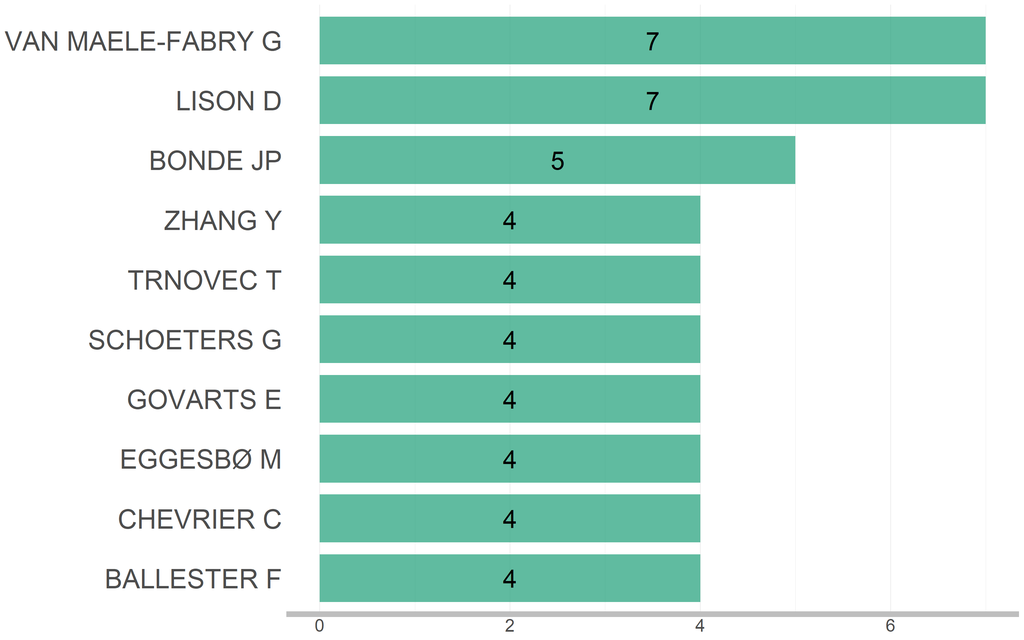

```r
authors_data <- bibliometric_analysis$Authors
authors_tibble <- as_tibble(authors_data)

# Slice top 10 authors
authors_tibble_filtered <- authors_tibble %>%
  slice_head(n = 10)

bar_plot_authors <- ggplot(authors_tibble_filtered, aes(y = n, x = reorder(AU, n))) +
  geom_bar(stat = "identity", width = 0.8, alpha = 0.7, fill = "#1b9e77") +
  geom_text(aes(label = n, y = n/2), hjust = 0.5, color = "black", size = 10) +
  coord_flip() +
  organochlorTHEME()

bar_plot_authors
```

```r
# ggsave(here("figures", "bar_plot_top_authors.pdf"), width = 25, height = 15, units = "cm", scale = 2, dpi = 800)
# ggsave(here("figures", "bar_plot_top_authors.svg"), width = 25, height = 15, units = "cm", scale = 2, dpi = 800)
```

## Figure 5

Heat map of world showing the country-level counts for first authors’ country of affiliation of meta-analysis investigating the impacts of organochlorine pesticides. Grey indicates no publications affiliated with a given country in our data set.

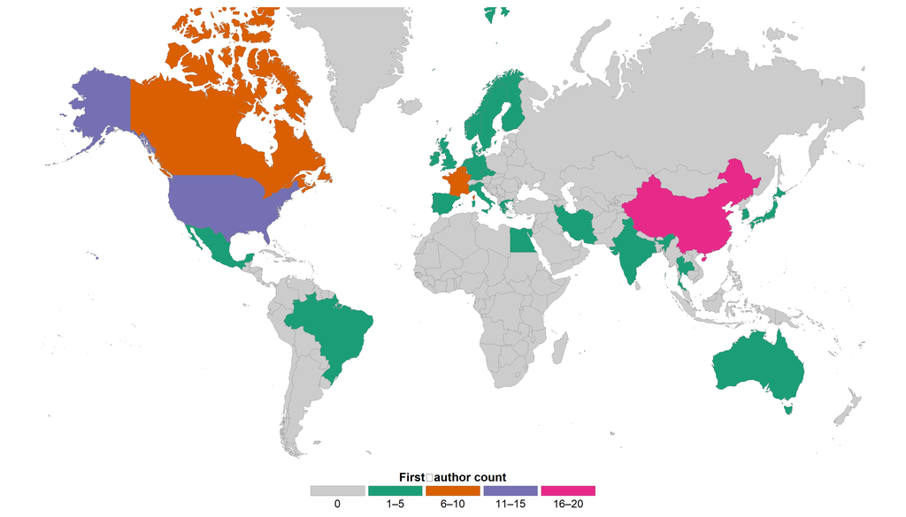

```r
# Extract country information from the "AU1_CO" and "AU_CO" fields of the "bib_sco" dataset
bibmap <- metaTagExtraction(bib_sco, Field = "AU1_CO", sep = ";")
bibmap <- metaTagExtraction(bibmap, Field = "AU_CO", sep = ";")

# Create a data frame with counts of articles from each country
firstcountrycounts <- bibmap %>%
  group_by(AU1_CO) %>%
  count() %>%
  filter(!is.na(AU1_CO))

# Load world map data and remove countries with longitude >180 to make an equal projection-like map
world_map <- map_data("world") %>%
  filter(! long > 180)

# Format country names to match regions on the world map
firstcountrycounts$region <- str_to_title(firstcountrycounts$AU1_CO)
firstcountrycounts$region[firstcountrycounts$region == "Usa"] <- "USA"
firstcountrycounts$region[firstcountrycounts$region == "Korea"] <- "South Korea"
firstcountrycounts$region[firstcountrycounts$region == "United Kingdom"] <- "UK"

# Join count data with map data and set missing counts to zero
emptymap <- tibble(region = unique(world_map$region), n = rep(0,length(unique(world_map$region))))
fullmap <- left_join(emptymap, firstcountrycounts, by = "region")
fullmap$n <- fullmap$n.x + fullmap$n.y
fullmap$n[is.na(fullmap$n)] <- 0

library(tidyverse)
library(RColorBrewer)

# 1. Create 4 count bands that will map cleanly to Dark2’s first 4 colours
fullmap <- fullmap %>%
  mutate(n_cat = cut(
    n,
    breaks  = c(0, 5, 10, 15, Inf),          # adjust if you prefer other cut‑points
    labels  = c("1–5", "6–10", "11–15", "16–20"),
    right   = TRUE, include.lowest = TRUE
  ))

# 1. recode counts into 5 tidy factor levels (0, 1–5, 6–10, 11–15, 16–20+)
fullmap <- fullmap %>%
  mutate(
    n_cat = case_when(
      is.na(n) ~ NA_character_,      # keep missing separate
      n == 0  ~ "0",
      n <= 5  ~ "1–5",
      n <= 10 ~ "6–10",
      n <= 15 ~ "11–15",
      TRUE    ~ "16–20"
    ) %>%
    factor(levels = c("0", "1–5", "6–10", "11–15", "16–20"))  # lock legend order
  )

# 2. define colours: grey for 0, first four Dark2 hues for the rest
fill_cols <- c(
  "0"        = "grey80",
  setNames(brewer.pal(4, "Dark2"), c("1–5", "6–10", "11–15", "16–20"))
)

# 3. build the map
fig5 <- fullmap %>%
  ggplot(aes(fill = n_cat, map_id = region)) +
  geom_map(map = world_map, colour = "gray50", linewidth = 0.2) +
  expand_limits(x = world_map$long, y = world_map$lat) +
  coord_map("mercator", xlim = c(-180, 180), ylim = c(-50, 90)) +
  scale_fill_manual(
    values   = fill_cols,
    name     = "First‑author count",
    na.value = "white",              # countries not in the data
    drop     = FALSE
  ) +
  theme_void() +
  theme(
    panel.background = element_rect(fill = "white", colour = NA),
    legend.position  = "bottom",
    legend.direction = "horizontal",
    legend.title     = element_text(size = 20, face = "bold"),
    legend.text      = element_text(size = 18),
    legend.key.width = unit(32, "mm"),
    legend.margin    = margin(t = 8)
  ) +
  guides(
    fill = guide_legend(
      title.position = "top",
      title.hjust    = 0.5,
      label.position = "bottom",
      nrow           = 1
    )
  )

fig5
```

```r
# ggsave(here("figures", "fig5.pdf"), width = 21, height = 12, units = "cm", scale = 2, dpi = 800)
# ggsave(here("figures", "fig5.svg"), width = 21, height = 12, units = "cm", scale = 2, dpi = 800)
```